# Tugas Kelompok MPDW Pertemuan 10

### GARCH(1,2)

AIC=19.053

```r
garchSpec12 <- ugarchspec(
  variance.model=list(model="sGARCH",
                      garchOrder=c(1,2)),
mean.model=list(armaOrder=c(1,0)))
garchFit12 <- ugarchfit(spec=garchSpec12, data=train.ts)
garchFit12
```

```
##
## *---------------------------------*
## *          GARCH Model Fit        *
## *---------------------------------*
##
## Conditional Variance Dynamics
## -----------------------------------
## GARCH Model  : sGARCH(1,2)
## Mean Model   : ARFIMA(1,0,0)
## Distribution : norm
##
## Optimal Parameters
## ------------------------------------
##          Estimate  Std. Error  t value Pr(>|t|)
## mu     3.0203e+04  1.3881e+03 21.75812 0.000000
## ar1    8.6734e-01  3.9453e-02 21.98402 0.000000
## omega  6.6223e+04  1.9200e+05  0.34492 0.730156
## alpha1 2.2555e-01  4.0943e-02  5.50884 0.000000
## beta1  2.3189e-01  1.7159e-01  1.35141 0.176564
## beta2  5.4156e-01  1.7954e-01  3.01643 0.002558
##
## Robust Standard Errors:
##          Estimate  Std. Error  t value Pr(>|t|)
## mu     3.0203e+04  2.5927e+03 11.64934 0.000000
## ar1    8.6734e-01  8.1756e-02 10.60884 0.000000
## omega  6.6223e+04  4.9052e+05  0.13501 0.892607
## alpha1 2.2555e-01  7.4520e-02  3.02670 0.002472
## beta1  2.3189e-01  2.8594e-01  0.81098 0.417379
## beta2  5.4156e-01  3.8719e-01  1.39869 0.161907
##
## LogLikelihood : -2375.612
##
## Information Criteria
## ------------------------------------
##
## Akaike       19.053
## Bayes        19.137
## Shibata      19.052
## Hannan-Quinn 19.087
##
```

[output cut: 43 more lines]

```
## Negative Sign Bias 0.007867 0.9937
## Positive Sign Bias 1.117745 0.2648
## Joint Effect       1.727009 0.6309
##
##
## Adjusted Pearson Goodness-of-Fit Test:
## ------------------------------------
##   group statistic p-value(g-1)
## 1    20     60.56    3.155e-06
## 2    30     76.16    4.164e-06
## 3    40     94.32    1.756e-06
## 4    50    110.00    1.396e-06
##
##
## Elapsed time : 0.107291
```

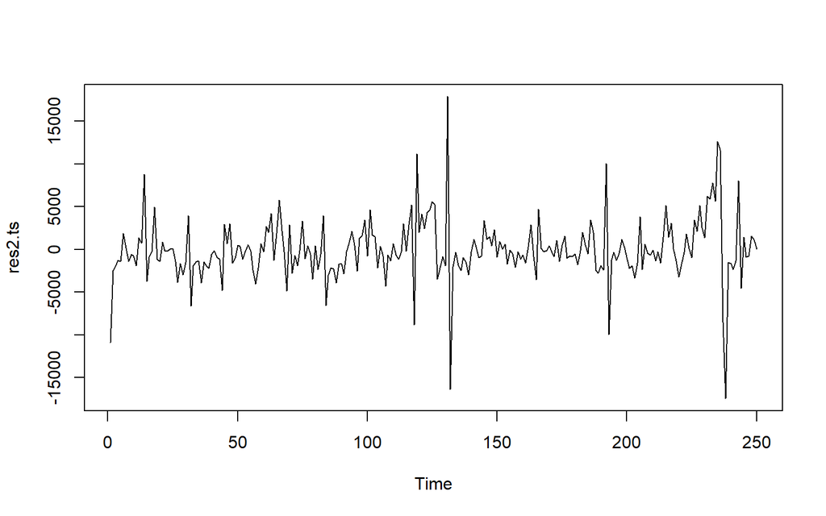

```r
res2<-garchFit12@fit$residuals
res2.ts<-ts(res2)
plot.ts(res2.ts)
```

### GARCH(2,1)

AIC=19.070

```r
garchSpec21 <- ugarchspec(
  variance.model=list(model="sGARCH",
                      garchOrder=c(2,1)),
mean.model=list(armaOrder=c(1,0)))
garchFit21 <- ugarchfit(spec=garchSpec21, data=train.ts)
garchFit21
```

```
##
## *---------------------------------*
## *          GARCH Model Fit        *
## *---------------------------------*
##
## Conditional Variance Dynamics
## -----------------------------------
## GARCH Model  : sGARCH(2,1)
## Mean Model   : ARFIMA(1,0,0)
## Distribution : norm
##
## Optimal Parameters
## ------------------------------------
##          Estimate  Std. Error   t value Pr(>|t|)
## mu     3.0203e+04  1.4744e+03 20.484687 0.000000
## ar1    8.6799e-01  4.3139e-02 20.120962 0.000000
## omega  6.6223e+04  1.2587e+05  0.526139 0.598792
## alpha1 1.6937e-01  3.6425e-02  4.649804 0.000003
## alpha2 0.0000e+00  5.5391e-02  0.000005 0.999996
## beta1  8.2963e-01  4.1446e-02 20.017230 0.000000
##
## Robust Standard Errors:
##          Estimate  Std. Error  t value Pr(>|t|)
## mu     3.0203e+04  3.4949e+03 8.641933 0.000000
## ar1    8.6799e-01  9.8005e-02 8.856655 0.000000
## omega  6.6223e+04  3.1920e+05 0.207469 0.835644
## alpha1 1.6937e-01  8.0762e-02 2.097128 0.035982
## alpha2 0.0000e+00  1.3762e-01 0.000002 0.999998
## beta1  8.2963e-01  1.0361e-01 8.007354 0.000000
##
## LogLikelihood : -2377.742
##
## Information Criteria
## ------------------------------------
##
## Akaike       19.070
## Bayes        19.154
## Shibata      19.069
## Hannan-Quinn 19.104
##
```

[output cut: 43 more lines]

```
## Negative Sign Bias 0.06417 0.9489
## Positive Sign Bias 1.25990 0.2089
## Joint Effect       2.32283 0.5082
##
##
## Adjusted Pearson Goodness-of-Fit Test:
## ------------------------------------
##   group statistic p-value(g-1)
## 1    20     53.20    4.367e-05
## 2    30     81.92    6.044e-07
## 3    40     91.12    4.688e-06
## 4    50    102.40    1.221e-05
##
##
## Elapsed time : 0.1151321
```

## Forecasting

Peramalan dilakukan untuk 45 periode ke depan.

### Plot Peramalan Pada Model

```r
forc <- ugarchforecast(garchFit12, data = train.ts, n.ahead = 45)
forc
```

```
##
## *------------------------------------*
## *       GARCH Model Forecast         *
## *------------------------------------*
## Model: sGARCH
## Horizon: 45
## Roll Steps: 0
## Out of Sample: 0
##
## 0-roll forecast [T0=250-01-01]:
##      Series Sigma
## T+1   32325  4420
## T+2   32044  4616
## T+3   31800  4516
## T+4   31588  4575
## T+5   31404  4548
## T+6   31245  4568
## T+7   31107  4562
## T+8   30987  4570
## T+9   30883  4571
## T+10  30793  4576
## T+11  30714  4578
## T+12  30646  4582
## T+13  30588  4585
## T+14  30537  4588
## T+15  30492  4591
## T+16  30454  4594
## T+17  30421  4597
## T+18  30392  4601
## T+19  30367  4604
## T+20  30345  4607
## T+21  30326  4610
## T+22  30310  4613
## T+23  30296  4616
## T+24  30283  4620
## T+25  30273  4623
## T+26  30263  4626
## T+27  30255  4629
## T+28  30248  4632
## T+29  30242  4635
## T+30  30237  4638
## T+31  30233  4642
## T+32  30229  4645
## T+33  30225  4648
## T+34  30222  4651
## T+35  30220  4654
## T+36  30218  4657
## T+37  30216  4660
## T+38  30214  4663
## T+39  30212  4666
## T+40  30211  4669
## T+41  30210  4673
## T+42  30209  4676
## T+43  30208  4679
## T+44  30208  4682
## T+45  30207  4685
```

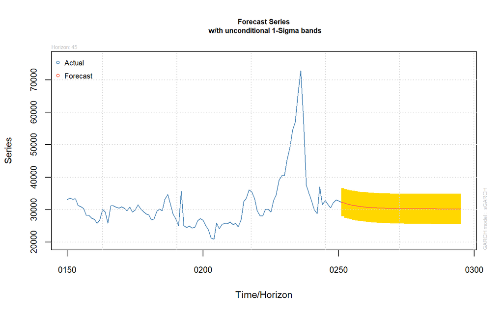

```r
plot(forc,which=1)
```

```r
forecastValues <- as.numeric(forc@forecast$seriesFor)
```

### Akurasi

```r
perbandingan<-matrix(data=c(head(test.ts, n=45), forecastValues),
                     nrow = 45, ncol = 2)
colnames(perbandingan)<-c("Aktual","Hasil Forecast")
perbandingan
```

```
##       Aktual Hasil Forecast
##  [1,]  33850       32325.37
##  [2,]  36900       32043.81
##  [3,]  34550       31799.60
##  [4,]  35150       31587.79
##  [5,]  32500       31404.08
##  [6,]  32050       31244.74
##  [7,]  32800       31106.53
##  [8,]  33550       30986.67
##  [9,]  34150       30882.70
## [10,]  35000       30792.53
## [11,]  35000       30714.32
## [12,]  36600       30646.48
## [13,]  39300       30587.65
## [14,]  41200       30536.62
```

[output cut: 31 more lines]

```r
accuracy(ts(forecastValues), head(test.ts, n=45))
```

```
##               ME     RMSE      MAE      MPE     MAPE      ACF1 Theil's U
## Test set 3937.64 6609.806 5700.577 8.967516 16.31754 0.8067138  2.440004
```

MAPE = 16.31754

## Pemodelan

ARMA(1,0) X GARCH(1,2)

```r
coef(garchFit12)
```

```
##           mu          ar1        omega       alpha1        beta1        beta2
## 3.020299e+04 8.673369e-01 6.622346e+04 2.255494e-01 2.318874e-01 5.415632e-01
```

Mean Model: $Y_t=0.8673Y_{t-1}+e_t$

Variance Model: $\sigma^2_t=66223.46+0.2255e^2_{t-1}+0.2319\sigma^2_{t-1}+0.5416\sigma^2_{t-2}$

## TGARCH

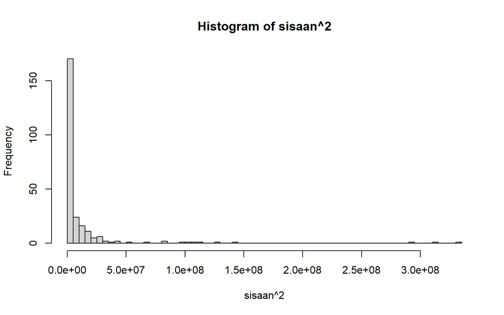

```r
hist(sisaan^2,breaks=50)
```

histogram sisaan kuadrat menjulur ke kanan maka akan dicoba model TGARCH

```r
signbias(garchFit12)
```

```
##                        t-value      prob sig
## Sign Bias          0.091442476 0.9272157
## Negative Sign Bias 0.007867113 0.9937294
## Positive Sign Bias 1.117744594 0.2647709
## Joint Effect       1.727009106 0.6309458
```

### TGARCH(1,0)

AIC = 18.71579

```r
spec10 <- ugarchspec(
  variance.model = list(model = "fGARCH", garchOrder = c(1,0), submodel = "TGARCH"),
  mean.model = list(armaOrder = c(1,0), include.mean = TRUE),
  distribution.model = "std"
)

fgarch.t10 <- ugarchfit(data = train.ts, spec = spec10, solver = "solnp")
infocriteria(fgarch.t10)
```

```
##
## Akaike       18.71579
## Bayes        18.80030
## Shibata      18.71467
## Hannan-Quinn 18.74980
```

```r
#fgarch.t10@fit$coef
```

### TGARCH(0,1)

AIC = 18.82830

```r
spec01 <- ugarchspec(
  variance.model = list(model = "fGARCH", garchOrder = c(0,1), submodel = "TGARCH"),
  mean.model = list(armaOrder = c(1,0), include.mean = TRUE),
  distribution.model = "std"
)

fgarch.t01 <- ugarchfit(data = train.ts, spec = spec01, solver = "solnp")
infocriteria(fgarch.t01)
```

```
##
## Akaike       18.82830
## Bayes        18.89873
## Shibata      18.82752
## Hannan-Quinn 18.85664
```

```r
#fgarch.t01@fit$coef
```

### TGARCH(1,1)

AIC = 18.73232

```r
spec11 <- ugarchspec(
  variance.model = list(model = "fGARCH", garchOrder = c(1,1), submodel = "TGARCH"),
  mean.model = list(armaOrder = c(1,0), include.mean = TRUE),
  distribution.model = "std"
)

fgarch.t11 <- ugarchfit(data = train.ts, spec = spec11, solver = "solnp")
infocriteria(fgarch.t11)
```

```
##
## Akaike       18.73232
## Bayes        18.83092
## Shibata      18.73081
## Hannan-Quinn 18.77200
```

```r
#fgarch.t11@fit$coef
```

### TGARCH(2,1)

AIC = 18.86273

```r
spec21 <- ugarchspec(
  variance.model = list(model = "fGARCH", garchOrder = c(2,1), submodel = "TGARCH"),
  mean.model = list(armaOrder = c(1,0), include.mean = TRUE),
  distribution.model = "std"
)

fgarch.t21 <- ugarchfit(data = train.ts, spec = spec21, solver = "solnp")
infocriteria(fgarch.t21)
```

```
##
## Akaike       18.86273
## Bayes        18.98950
## Shibata      18.86025
## Hannan-Quinn 18.91375
```

```r
#fgarch.t21@fit$coef
```

### TGARCH(1,2)

AIC = 18.73478

```r
spec12 <- ugarchspec(
  variance.model = list(model = "fGARCH", garchOrder = c(1,2), submodel = "TGARCH"),
  mean.model = list(armaOrder = c(1,0), include.mean = TRUE),
  distribution.model = "std"
)

fgarch.t12 <- ugarchfit(data = train.ts, spec = spec12, solver = "solnp")
infocriteria(fgarch.t12)
```

```
##
## Akaike       18.73478
## Bayes        18.84747
## Shibata      18.73282
## Hannan-Quinn 18.78014
```

```r
#fgarch.t12@fit$coef
```

## Forecasting TGARCH

Peramalan dilakukan untuk 45 periode ke depan.

### Plot Peramalan Pada Model

```r
forctg <- ugarchforecast(fgarch.t01, data = train.ts, n.ahead = 45)
forctg
```

```
##
## *------------------------------------*
## *       GARCH Model Forecast         *
## *------------------------------------*
## Model: fGARCH
## fGARCH Sub-Model: TGARCH
##
## Horizon: 45
## Roll Steps: 0
## Out of Sample: 0
##
## 0-roll forecast [T0=250-01-01]:
##      Series Sigma
## T+1   32456  7768
## T+2   32267  7768
## T+3   32084  7768
## T+4   31907  7768
## T+5   31734  7768
## T+6   31566  7768
## T+7   31404  7768
## T+8   31246  7768
## T+9   31093  7768
## T+10  30944  7768
## T+11  30800  7768
## T+12  30659  7768
## T+13  30523  7768
## T+14  30391  7768
## T+15  30263  7768
## T+16  30138  7768
## T+17  30017  7768
## T+18  29900  7768
## T+19  29786  7768
## T+20  29675  7768
## T+21  29568  7768
## T+22  29463  7768
## T+23  29362  7768
## T+24  29264  7768
## T+25  29168  7768
## T+26  29076  7768
## T+27  28986  7768
## T+28  28898  7768
## T+29  28814  7768
## T+30  28731  7768
## T+31  28651  7768
## T+32  28574  7768
## T+33  28498  7768
## T+34  28425  7768
## T+35  28354  7768
## T+36  28285  7768
## T+37  28218  7768
## T+38  28153  7768
## T+39  28090  7768
## T+40  28029  7768
## T+41  27970  7768
## T+42  27912  7768
## T+43  27856  7768
## T+44  27802  7768
## T+45  27749  7768
```

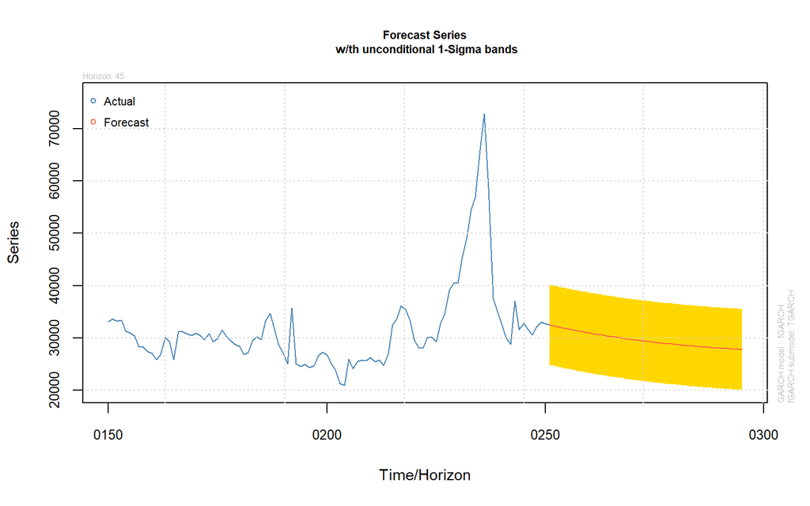

```r
plot(forctg,which=1)
```

```r
forecastValuestg <- as.numeric(forctg@forecast$seriesFor)
```

### Akurasi

```r
perbandingantg<-matrix(data=c(head(test.ts, n=45), forecastValuestg),
                     nrow = 45, ncol = 2)
colnames(perbandingantg)<-c("Aktual","Hasil Forecast")
perbandingantg
```

```
##       Aktual Hasil Forecast
##  [1,]  33850       32455.79
##  [2,]  36900       32267.25
##  [3,]  34550       32084.21
##  [4,]  35150       31906.51
##  [5,]  32500       31733.98
##  [6,]  32050       31566.49
##  [7,]  32800       31403.89
##  [8,]  33550       31246.03
##  [9,]  34150       31092.77
## [10,]  35000       30943.98
## [11,]  35000       30799.53
## [12,]  36600       30659.29
## [13,]  39300       30523.15
## [14,]  41200       30390.97
```

[output cut: 31 more lines]

```r
accuracy(ts(forecastValuestg), head(test.ts, n=45))
```

```
##                ME     RMSE      MAE      MPE     MAPE      ACF1 Theil's U
## Test set 4878.894 7081.446 5928.138 11.99813 16.41929 0.8057766  2.486328
```

MAPE = 16.41929